# Sacramento River

Sadie Gill, Mark Tompkins, Erin Cain

June 18, 2019

## Future Data Improvement

None Planned

## Instream Spawning and Rearing Habitat

**Data Source:** [FWS 2003](https://www.fws.gov/lodi/instream-flow/Documents/Sacramento%20River%20Spawning%20Final%20Report%20Feb%204,%202003.pdf) (pg 29-31)

Spawning habitat area for Chinook Salmon (Fall Run, Late Fall Run, Winter Run) and Steelhead are based on data from a US Fish and Wildlife Service 2003 study of spawning habitat in the Sacramento River between Keswick Dam and the confluence with Battle Creek. The spawning WUA source data was developed in six study segments. One of the study segments considers conditions with and without the Anderson Cottonwood Irrigation District (A.C.I.D.) diversion dam. The A.C.I.D. boards are in April 1st - October 31st. The Upper Sacramento fall run spawning WUA values include the spawning that occurs Keswick to Deer Creek. The Late-Fall Run, Winter Run, and Steelhead spawn from Keswick to Battle Creek. Within the lifecycle model, spawning only occurs on the Sacramento River in the Upper Sacramento River reach, this habitat area includes the area of both the Upper Sacramento River and Upper Mid-Sacramento River reaches combined. Mark Gard from the U.S. Fish and Wildlife Service provided the data (see ‘Sacramento’ tab in ‘~/cvpiaHabitat/data-raw/mark_gard_data/IFIMWUA.xlsx’). The data has been reorganized for clarity see (‘~/cvpiaHabitat/data-raw/instream/sacramento/upper_sacramento_river_instream’).

Instream and floodplain rearing habitat areas are based on habitat modeling conducted by NOAA NMFS for their Winter Run Chinook Salmon life cycle model. The entire mapped rearing extent of the Sacramento River was modeled using the Central Valley Floodplain Evaluation and Delineation (CVFED) HEC-RAS hydraulic model refined for use in their Winter Run Chinook Salmon life cycle model. NOAA NMFS provided tabular suitable rearing habitat area data for three reaches of the Sacramento River (Keswick to Battle Creek, Battle Creek to Feather River, and Feather River to Freeport). The high quality depth and high quality velocity criteria (“Pref11”) “ChanArea” value was used for instream habitat and “BankArea” result was used as floodplain area. High quality velocities were assumed to be less than or equal to 0.15 meters per second, and high quality depths were assumed to be between 0.2 meters and 1.5 meters.

### Spawning WUA

#### Spawning Habitat (A.C.I.D boards in)

| flow_cfs | FR_spawn_WUA | LFR_spawn_WUA | ST_spawn_WUA | WR_spawn_WUA | watershed |
| --- | --- | --- | --- | --- | --- |
| 3250 | 8553.719 | 7945.461 | 1998.007 | 5321.020 | Upper Sacramento River |
| 3500 | 8756.922 | 8204.024 | 2034.904 | 5627.105 | Upper Sacramento River |
| 3750 | 8939.986 | 8329.719 | 2041.319 | 5880.905 | Upper Sacramento River |
| 4000 | 9069.236 | 8394.523 | 2025.323 | 6111.320 | Upper Sacramento River |
| 4250 | 9082.162 | 8429.446 | 2009.004 | 6350.286 | Upper Sacramento River |

*…with 25 more rows.*

#### Spawning Habitat (A.C.I.D boards out)

| flow_cfs | FR_spawn_WUA | LFR_spawn_WUA | ST_spawn_WUA | WR_spawn_WUA | watershed |
| --- | --- | --- | --- | --- | --- |
| 3250 | 8679.536 | 8426.900 | 1685.370 | 6987.003 | Upper Sacramento River |
| 3500 | 8818.288 | 8558.582 | 1730.260 | 7311.780 | Upper Sacramento River |
| 3750 | 8939.287 | 8562.543 | 1748.125 | 7569.374 | Upper Sacramento River |
| 4000 | 9007.222 | 8508.830 | 1746.330 | 7789.940 | Upper Sacramento River |
| 4250 | 8966.538 | 8439.785 | 1741.729 | 8004.645 | Upper Sacramento River |

*…with 25 more rows.*

#### Spawning WUAs Plot

The following plot shows the weighted usable spawning area in square feet per thousand feet of river for Fall Run Chinook, Late-fall Run Chinook, Winter Run Chinook, and Steelhead. These area per length rates are multiplied by the total spawning reach length mapped by the SIT.

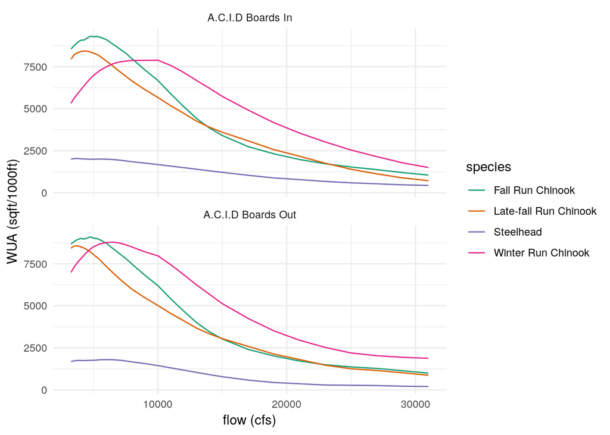

### Rearing WUA

The juvenile instream high quality rearing habitat for Winter Run Chinook Salmon in the Sacramento River is used as a surrogate for the other present Chinook runs. Units are in square meters.

#### Upper Sacramento River Instream Rearing

| flow_cfs | rearing_sq_meters | watershed |
| --- | --- | --- |
| 2000 | 408108.4 | Upper Sacramento River |
| 2500 | 328336.6 | Upper Sacramento River |
| 3000 | 300066.5 | Upper Sacramento River |
| 3500 | 256124.3 | Upper Sacramento River |
| 4000 | 296282.6 | Upper Sacramento River |

*…with 76 more rows.*

#### Upper-mid Sacramento River Instream Rearing

| flow_cfs | rearing_sq_meters | watershed |
| --- | --- | --- |
| 2000 | 878413.6 | Upper-mid Sacramento River |
| 2500 | 741025.1 | Upper-mid Sacramento River |
| 3000 | 651171.6 | Upper-mid Sacramento River |
| 3500 | 534196.4 | Upper-mid Sacramento River |
| 4000 | 509043.3 | Upper-mid Sacramento River |

*…with 76 more rows.*

#### Lower-mid Sacramento River Instream Rearing

| flow_cfs | rearing_sq_meters | watershed |
| --- | --- | --- |
| 2000 | 588830.0 | Lower-mid Sacramento River |
| 2500 | 511765.5 | Lower-mid Sacramento River |
| 3000 | 433134.1 | Lower-mid Sacramento River |
| 3500 | 370989.6 | Lower-mid Sacramento River |
| 4000 | 333820.6 | Lower-mid Sacramento River |

*…with 76 more rows.*

#### Lower Sacramento River Instream Rearing

| flow_cfs | rearing_sq_meters | watershed |
| --- | --- | --- |
| 2000 | 141024.84 | Lower Sacramento River |
| 2500 | 125106.62 | Lower Sacramento River |
| 3000 | 103166.84 | Lower Sacramento River |
| 3500 | 91030.76 | Lower Sacramento River |
| 4000 | 78698.88 | Lower Sacramento River |

*…with 76 more rows.*

#### Chinook Salmon Instream Rearing Area Plot

The following plot shows the flow to highly suitable area in acres for Chinook Salmon juveniles.

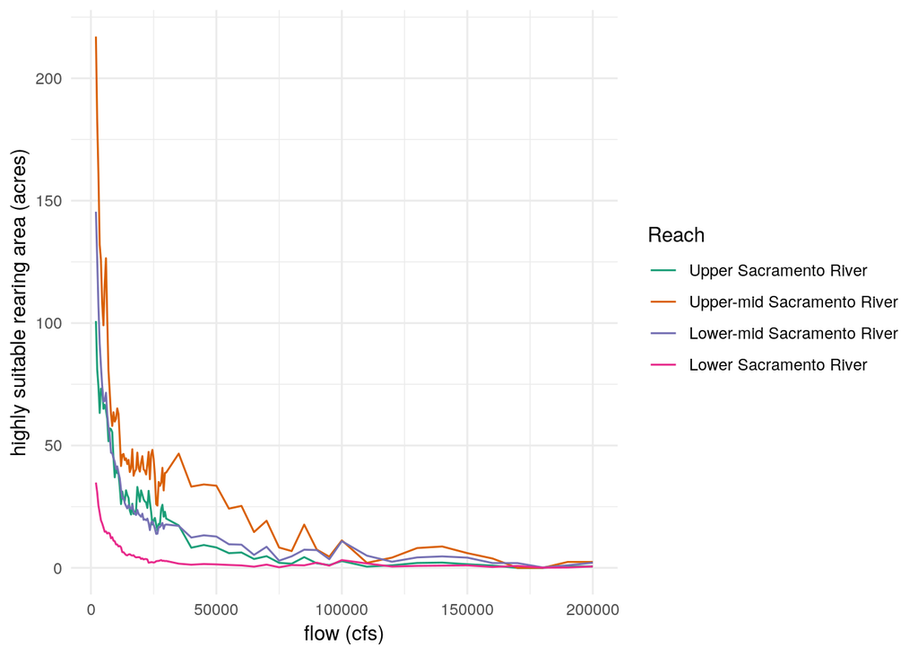